# 121140068_ho3

## Hands-on 3

by Arsyadana Estu Aziz (121140068)

This Hands-on consist of several steps, it consist of 6 question and each question is different. The sample being used in here is on the `attachment` folder, on file `sample-renamed.mp4`

### Task 1

Dari bagian kode ini:

```
list_imgs = sorted(list_imgs, key=lambda x: int(x.split('/')[-1].split('.')[0]))
print(f"5 path pertama setelah diurutkan: {list_imgs[:5]}")
print(f"Total jumlah gambar: {len(list_imgs)}")
```

Kode ini bertujuan untuk mengurutkan (sorting) pada daftar gambar berdsarkan *key* yang ditentukan dalam *lambda function* seperti berikut.

- `x.split('/')[-1]`, berfungsi untuk memisahkan string menjadi beberapa item dalam list, dan akan di ambil item terakhir.
- `.split('.')[0]`, berfungsi untuk memisahkan item terakhir (berupa filename gambar) dan memisahkan filename dan extensi, lalu kita bisa mengambil filename sebagai key dalam proses konversi.
- `int()`, berfungsi untuk mengkonvensi string menjadi nilai integer.

Liat pada kasus ini, misalkan `list_imgs` berisi:

```
list_imgs = ['path/to/image/1.jpg', 'path/to/image/10.jpg', 'path/to/image/2.jpg']
```

Proses untuk setiap item akan seperti berikut:

1. Split `/`: `x.split('/')` akan memberikan `['path', 'to', 'image', '1.jpg']`
2. Split `.`: `'1.jpg'.split('.')` akan menghasilkan daftar: ['1', 'jpg'] Mengambil elemen pertama dengan [0]: `1`
3. Konversi ke Integer: `int('1')` akan menghasilkan: 1

### Task 2

Jelaskan tentang bagian kode berikut:

```
fourcc = cv2.VideoWriter_fourcc(*'mp4v')
```

Dalam `OpenCV`, `FOURCC` (Four Character Code) adalah 4-byte code yang digunakan untuk encoding / decoding dari sebuah video. Normalnya, setiap video containers memiliki format codec-nya sendiri seperti berikut:

- XVID: MPEG-4 codec (often used for AVI files).
- MJPG: Motion JPEG codec.
- DIVX: DivX MPEG-4 codec.
- H264: H.264 codec (requires additional software support).
- MP4V: MPEG-4 codec for MP4 files.
- I420: Uncompressed YUV format.

Apa yang terjadi jika codec tidak sesuai dengan video container? Tidak ada kesalahan fatal, karena media player saat ini bisa mendukung berbagai macam codec, terlepas dari container format itu sendiri.

### Import Dependencies

```python
import os
from glob import glob
import cv2
import numpy as np
import matplotlib.pyplot as plt
import dlib
import datetime as dt
```

## Playing the video input

Memasukan file sebagai sampel processing

```python
video_path = os.path.join(os.getcwd(), 'attachment', 'sample-renamed.mp4')

if not os.path.exists(video_path):
    print("Video file not found")
    exit(1)

cap = cv2.VideoCapture(video_path)

vid_np = []
i = 0

while i < 150:
    # membaca frame
    ret, frame = cap.read()

    # jika frame sudah habis, maka break (keluar dari loop)
    if not ret:
        break

    # pindahin frame ke `vid_np`
    vid_np.append(frame)

    # nampilin frame
    # cv2.imshow('Video', frame) # saya comment karena error di MacOS baru

    # jika tombol `q` ditekan, maka video akan berhenti
    if cv2.waitKey(1) & 0xFF == ord('q'):
        break

    i += 1

cap.release()
cv2.destroyAllWindows()

vid_np = np.array(vid_np)

print(f"Shape dari `vid_np` adalah {vid_np.shape}")
```

```
Shape dari `vid_np` adalah (150, 1080, 1920, 3)
```

### Showing some of the frames video

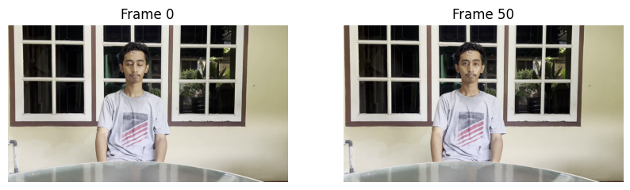

```python
img_frame0 = vid_np[0]
img_frame1 = vid_np[50]

plt.figure(figsize=(10, 10))
plt.subplot(1, 2, 1)
plt.imshow(cv2.cvtColor(img_frame0, cv2.COLOR_BGR2RGB))
plt.title('Frame 0')
plt.axis('off')

plt.subplot(1, 2, 2)
plt.imshow(cv2.cvtColor(img_frame1, cv2.COLOR_BGR2RGB))
plt.title('Frame 50')
plt.axis('off')

plt.show()
```

### Task 3

Converting a video into lowest third FPS of the orignal (since the every frame is taken every third), convert into grayscale and create a dot effect manually (not with the `cv2.cirlce()`)

```python
import cv2
import numpy as np
import os

# Paths video
original_video_path = os.path.join(os.getcwd(), 'attachment', 'sample-renamed.mp4')
low_fps_video_path = os.path.join(os.getcwd(), 'attachment', 'video_low_fps.mp4')

# Initialize video capture
videoCapture = cv2.VideoCapture(original_video_path)

# Check if video opened successfully
if not videoCapture.isOpened():
    print("Error: Could not open video.")
    exit()

# Get original FPS and frame count
fps = videoCapture.get(cv2.CAP_PROP_FPS)
frame_count = int(videoCapture.get(cv2.CAP_PROP_FRAME_COUNT))
print(f'Original FPS: {fps}')
print(f'Total Frames: {frame_count}')

# Calculate new FPS (reduce by taking every 3rd frame)
new_fps = fps / 3
print(f'New FPS: {new_fps}')

# Define frame size
frame_size = (1280, 720)  # (width, height)

# Initialize video writer
fourcc = cv2.VideoWriter_fourcc(*'mp4v')  # Codec
output = cv2.VideoWriter(low_fps_video_path, fourcc, new_fps, frame_size, isColor=True)

if not output.isOpened():
    print("Error: Could not open video writer.")
    videoCapture.release()
    exit()

frame_index = 0
processed_frame_num = 0  # To track the number of frames being written

# Calculate step for moving the dot across frames
# The dot should move from left (0) to right (frame_size[0]-1) over all processed frames
if frame_count // 3 > 1:
    step = (frame_size[0] - 1) / (frame_count // 3 - 1)
else:
    step = 0  # Avoid division by zero if only one frame is processed

while True:
    ret, frame = videoCapture.read()
    if not ret:
        break

    # Process every 3rd frame
    if frame_index % 3 == 0:
        # Resize to 1280x720
        resized_frame = cv2.resize(frame, frame_size)

        # Convert to grayscale
        gray_frame = cv2.cvtColor(resized_frame, cv2.COLOR_BGR2GRAY)

        # Convert grayscale back to BGR (to maintain 3 channels)
        bgr_frame = cv2.cvtColor(gray_frame, cv2.COLOR_GRAY2BGR)

        # Calculate the position of the red dot
        x = int(processed_frame_num * step)
        y = frame_size[1] // 2  # Center row (height)

        # Ensure x is within bounds
        x = min(x, frame_size[0] - 1)

        # Add the red dot manually
        # OpenCV uses BGR, so Red is [0, 0, 255]
        bgr_frame[y, x] = [0, 0, 255]

        # Or Easier one for displaying the dot
        # cv2.circle(bgr_frame, (x, y), 100, (0, 0, 255), -1)  # Increased radius to 10

        # Make the dot larger for visibility
        # Define the size of the dot
        dot_radius = 10
        for dy in range(-dot_radius, dot_radius + 1):
            for dx in range(-dot_radius, dot_radius + 1):
                if dx**2 + dy**2 <= dot_radius**2:
                    nx, ny = x + dx, y + dy
                    if 0 <= nx < frame_size[0] and 0 <= ny < frame_size[1]:
                        bgr_frame[ny, nx] = [0, 0, 255]

        # Debug: Print the RGB value of the dot
        print(f'Processed Frame {processed_frame_num}: Red dot at ({x}, {y}) with BGR value {bgr_frame[y, x]}')

        # Write the frame to the output video
        output.write(bgr_frame)

        processed_frame_num += 1

    frame_index += 1

print(f'Processed {processed_frame_num} frames.')

# Release resources
videoCapture.release()
output.release()
cv2.destroyAllWindows()
```

```
Original FPS: 30.0
Total Frames: 1800
New FPS: 10.0
Processed Frame 0: Red dot at (0, 360) with BGR value [  0   0 255]
Processed Frame 1: Red dot at (2, 360) with BGR value [  0   0 255]
Processed Frame 2: Red dot at (4, 360) with BGR value [  0   0 255]
Processed Frame 3: Red dot at (6, 360) with BGR value [  0   0 255]
Processed Frame 4: Red dot at (8, 360) with BGR value [  0   0 255]
Processed Frame 5: Red dot at (10, 360) with BGR value [  0   0 255]
Processed Frame 6: Red dot at (12, 360) with BGR value [  0   0 255]
Processed Frame 7: Red dot at (14, 360) with BGR value [  0   0 255]
Processed Frame 8: Red dot at (17, 360) with BGR value [  0   0 255]
Processed Frame 9: Red dot at (19, 360) with BGR value [  0   0 255]
Processed Frame 10: Red dot at (21, 360) with BGR value [  0   0 255]
Processed Frame 11: Red dot at (23, 360) with BGR value [  0   0 255]
Processed Frame 12: Red dot at (25, 360) with BGR value [  0   0 255]
Processed Frame 13: Red dot at (27, 360) with BGR value [  0   0 255]
Processed Frame 14: Red dot at (29, 360) with BGR value [  0   0 255]
Processed Frame 15: Red dot at (32, 360) with BGR value [  0   0 255]
Processed Frame 16: Red dot at (34, 360) with BGR value [  0   0 255]
Processed Frame 17: Red dot at (36, 360) with BGR value [  0   0 255]
Processed Frame 18: Red dot at (38, 360) with BGR value [  0   0 255]
Processed Frame 19: Red dot at (40, 360) with BGR value [  0   0 255]
Processed Frame 20: Red dot at (42, 360) with BGR value [  0   0 255]
Processed Frame 21: Red dot at (44, 360) with BGR value [  0   0 255]
Processed Frame 22: Red dot at (46, 360) with BGR value [  0   0 255]
Processed Frame 23: Red dot at (49, 360) with BGR value [  0   0 255]
Processed Frame 24: Red dot at (51, 360) with BGR value [  0   0 255]
Processed Frame 25: Red dot at (53, 360) with BGR value [  0   0 255]
Processed Frame 26: Red dot at (55, 360) with BGR value [  0   0 255]
Processed Frame 27: Red dot at (57, 360) with BGR value [  0   0 255]
Processed Frame 28: Red dot at (59, 360) with BGR value [  0   0 255]
Processed Frame 29: Red dot at (61, 360) with BGR value [  0   0 255]
Processed Frame 30: Red dot at (64, 360) with BGR value [  0   0 255]
Processed Frame 31: Red dot at (66, 360) with BGR value [  0   0 255]
Processed Frame 32: Red dot at (68, 360) with BGR value [  0   0 255]
Processed Frame 33: Red dot at (70, 360) with BGR value [  0   0 255]
Processed Frame 34: Red dot at (72, 360) with BGR value [  0   0 255]
Processed Frame 35: Red dot at (74, 360) with BGR value [  0   0 255]
Processed Frame 36: Red dot at (76, 360) with BGR value [  0   0 255]
```

[output cut: 549 more lines]

```
Processed Frame 586: Red dot at (1251, 360) with BGR value [  0   0 255]
Processed Frame 587: Red dot at (1253, 360) with BGR value [  0   0 255]
Processed Frame 588: Red dot at (1255, 360) with BGR value [  0   0 255]
Processed Frame 589: Red dot at (1257, 360) with BGR value [  0   0 255]
Processed Frame 590: Red dot at (1259, 360) with BGR value [  0   0 255]
Processed Frame 591: Red dot at (1261, 360) with BGR value [  0   0 255]
Processed Frame 592: Red dot at (1264, 360) with BGR value [  0   0 255]
Processed Frame 593: Red dot at (1266, 360) with BGR value [  0   0 255]
Processed Frame 594: Red dot at (1268, 360) with BGR value [  0   0 255]
Processed Frame 595: Red dot at (1270, 360) with BGR value [  0   0 255]
Processed Frame 596: Red dot at (1272, 360) with BGR value [  0   0 255]
Processed Frame 597: Red dot at (1274, 360) with BGR value [  0   0 255]
Processed Frame 598: Red dot at (1276, 360) with BGR value [  0   0 255]
Processed Frame 599: Red dot at (1279, 360) with BGR value [  0   0 255]
Processed 600 frames.
```

### Display the Low Fps Video and show some of the frames

```
Shape of frames_array: (600, 720, 1280, 3)
Length of a frame: (720, 1280, 3)
RGB value of the frame: [[200 203 201]
 [183 186 184]
 [143 146 144]
 ...
 [167 170 168]
 [167 170 168]
 [167 170 168]]
```

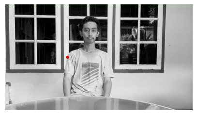

```python
low_fps_video_path = os.path.join(os.getcwd(), 'attachment', 'video_low_fps.mp4')

cap = cv2.VideoCapture(low_fps_video_path)
frames= []
while True:
    ret, frame = cap.read()
    if not ret:
        break
    frames.append(frame)

frames_array = np.array(frames)
cap.release()

print(f"Shape of frames_array: {frames_array.shape}")

# Extract R, G, B channels
r_channel, g_channel, b_channel = frames_array[:, :, 0], frames_array[:, :, 1], frames_array[:, :, 2]

## Print length of a  frame
print(f"Length of a frame: {frames_array[0].shape}")

## Print rgb value of this frame
print(f"RGB value of the frame: {frames_array[0][3]}")

single_img = frames_array[200].copy()
single_img = cv2.cvtColor(single_img, cv2.COLOR_BGR2RGB)

plt.figure(figsize=(5, 5))
plt.imshow(single_img)
plt.axis('off')
plt.show()
```

## Explanation

Video yang digunakan mempunyai durasi 60 detik dengan 30 fps. Karena akan di ambil setiap frame setiap 3 gambar, maka idealnya proses fps akan berkurang menjadi $\frac{30}{3} = 10$ fps. Dan memang hasil akhir video menunjukan 10 fps.

Untuk grayscale sendiri saya baru tahu, bahwasannya proses konversi dari RGB / BGR ke Grayscale dan sebaliknya hanya untuk menambah / menghapus 3 chanel warna dari sebuah frame video.

Informasi mengenai nilai RGB frame sebelumnya sudah hilang ketika dilakukan konversi dari RGB ke Grayscale, nilai grayscale tersebut akan tetap sama meskipun di konversi balik menjadi format RGB / BGR, hanya saja terdapat 3 chanel warna yang ditambahkan.

Setelah menambahkan 3 chanel warna, kita dapat melakukan proses penambahan titik pada pixel dan amplifikasi frame tersebut sehingga dapat terlihat dengan mudah di layar.

```
# Calculate the position of the red dot
    x = int(processed_frame_num * step)
    y = frame_size[1] // 2  # Center row (height)

    # Ensure x is within bounds
    x = min(x, frame_size[0] - 1)

    # Add the red dot manually
    # OpenCV uses BGR, so Red is [0, 0, 255]
    bgr_frame[y, x] = [0, 0, 255]
```

Proses ini akan menghitung posisi dari titik merah berdasarkan frame (karena kita membagi frame menjadi setiap 3 frame, maka red dot akan di gambar pada setiap 3 frame tersbut, lalu bergerak ke kanan).

Di sisi lain, dot merah ini masih terlalu kecil, maka akan dilakukan amplifikasi untuk menambah ukuran dari dot tersebut.

[output not shown]

Proses disini cukup sederhana, dot tersebut akan di amplifikasikan untuk setiap panjang dan lebar dari dot tersebut lalu di masukan ke frame.

## Detection with DLIB

### Task 4

Using DLIB, based on the Face ROI (Region of Interest) and expand for shoulder and chest

```python
## Moving the frame video into nuympy array
video_path = os.path.join(os.getcwd(), 'attachment', 'sample-renamed.mp4')

videoCapture = cv2.VideoCapture(video_path)
video_frames = []

## Adding the frames to the video_frames list
while True:
    ret, frame = videoCapture.read()
    if not ret:
        break
    ## Converting into RGB value
    frame = cv2.cvtColor(frame, cv2.COLOR_BGR2RGB)
    video_frames.append(frame)

frames_array = np.array(video_frames)
videoCapture.release()

## Print the shape of the frames_array
print(f"Shape of frames_array: {frames_array.shape}")
```

```
Shape of frames_array: (1800, 1080, 1920, 3)
```

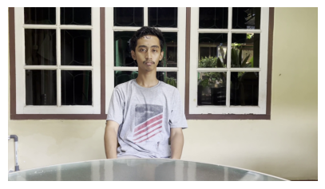

```python
## Showing a frame of the original image
single_img = frames_array[200].copy()
plt.figure(figsize=(5, 5))
plt.imshow(single_img)
plt.axis('off')
plt.show()
```

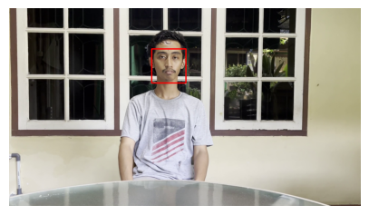

```python
detector = dlib.get_frontal_face_detector()

faces = detector(single_img, 1)
for i, face in enumerate(faces): # untuk setiap wajah yang terdeteksi (bisa saja lebih dari satu)
    x, y, w, h = face.left(), face.top(), face.width(), face.height()
    x2 = x + w
    y2 = y + h
    cv2.rectangle(single_img, (x, y), (x2, y2), (255, 0, 0), 5)

plt.figure(figsize=(5, 5))
plt.imshow(single_img)
plt.axis('off')
plt.show()
```

### Task 4

Based on the Face ROI (Expand for shoulder and chest)

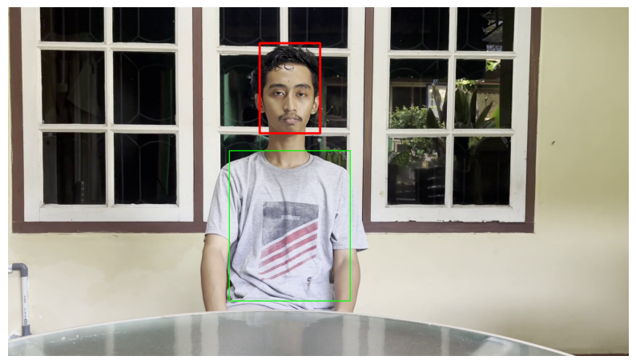

```python
## Setup the Dlib
detector = dlib.get_frontal_face_detector()

## Obtain a image and faces detection frame
single_img  = frames_array[200].copy()
faces = detector(single_img, 1)

## Loop through the faces and draw the bounding box
for face in faces:
    x, y, w, h = (face.left(), face.top(), face.width(), face.height())

    ## Adding the bounding box to the hair
    y_hair = int(y - (0.5 * y))
    h_hair = int(h + (0.5 * h))
    cv2.rectangle(single_img, (x, y_hair), (x2, h_hair + y_hair), (255, 0, 0), 5)


    # Adjust ROI to include shoulders and chest
    roi_x = int(x - (0.5 * w))
    roi_y = int(y * 2)
    roi_w = int(w * 2)
    roi_h = int(h * 2.5)  # Adjust the height to include shoulders and chest

    # Ensure the new ROI does not go out of frame bounds
    roi_h = min(roi_h, single_img.shape[0] - roi_y)

    # Draw rectangle around the adjusted ROI
    cv2.rectangle(single_img, (roi_x, roi_y), (roi_x+roi_w, roi_y+roi_h), (0, 255, 0), 2)

# Display the image with the adjusted bounding box
plt.figure(figsize=(10, 10))
plt.imshow(single_img)
plt.axis('off')
plt.show()
```

### Explanation

```
## Iteration
for i, face in enumerate(faces):
```

- **`for i, face in enumerate(faces)`**: Ini adalah loop yang akan berjalan sebanyak jumlah wajah yang terdeteksi.
  - **`enumerate(faces)`**: `enumerate` memberikan dua nilai untuk setiap iterasi loop:
    - `i`: Indeks dari wajah yang terdeteksi (dimulai dari 0).
    - `face`: Objek bounding box dari setiap wajah yang terdeteksi. Objek ini memiliki koordinat posisi wajah dalam gambar.

```
## Set domain
x, y, w, h = face.left(), face.top(), face.width(), face.height()
```

- **`face.left()`**: Mengambil koordinat x dari tepi kiri kotak pembatas (bounding box) wajah.
- **`face.top()`**: Mengambil koordinat y dari tepi atas kotak pembatas wajah.
- **`face.width()`**: Mengambil lebar bounding box wajah.
- **`face.height()`**: Mengambil tinggi bounding box wajah.
- **`x, y, w, h`**: Variabel ini menyimpan posisi dan ukuran dari bounding box wajah yang terdeteksi, di mana:
  - `x`: Koordinat x dari sudut kiri atas wajah.
  - `y`: Koordinat y dari sudut kiri atas wajah.
  - `w`: Lebar bounding box wajah.
  - `h`: Tinggi bounding box wajah.

```
## Set bouding for width
x2 = x + w
```

- **`x2 = x + w`**: Menghitung koordinat x dari sudut kanan bawah bounding box. Ini didapat dengan menjumlahkan nilai `x` (koordinat kiri atas) dengan `w` (lebar bounding box).

```
## Set bouding for height
y2 = y + h
```

- **`y2 = y + h`**: Menghitung koordinat y dari sudut kanan bawah bounding box. Ini didapat dengan menjumlahkan nilai `y` (koordinat kiri atas) dengan `h` (tinggi bounding box).

```
## Set bounding box for the face
cv2.rectangle(single_img, (x, y), (x2, y2), (255, 0, 0), 5)
```

### Bagian bahu

Untuk bagian dada dan bahu, kita dapat melakukan seleksi manual untuk membuat bounding box dengan mendaptkan nilai `x,y,w,h` dari wajah dan kita lakukan proses secara manual untuk membuat bounding box tersebut.

### Facial Tracking dengan Optical Flow

Menggunakan dlib untuk melakukan re-deteksi setiap frame, sangat tidak efisien dan akan memakan proses komputasi yang lama.

Proses facial tracking memungkinkan untuk prediksi identifikasi wajah untuk frame selanjutnya tanpa harus melakukan re-detetksi wajah

### Task 5

In seconds 25 - 40, using facial tracking for the face that got detected. Save the video in drive.

Here's the link of the video: [Link](https://drive.google.com/file/d/1d9ml1OR5M4Cy90rdI-jk7W563SHMLyls/view?usp=drive_link)

## Explanation

Proses facial tracking yang dilakukan pada file `video_processing` melakukan re-deteksi setiap 3 frame, bukanlah proses yang cukup efisien.

Lucas Canade Optical Flow cukup bagus ketika melakukan prediksi wajah pada objek yang stabil (tidak ada gerakan tiba-tiba). Namun untuk sampel video pada detik 25-40, terdapat gerakan kepala ke kiri dan kanan sehinggga bounding box ketika terjadi gerakan teresbut akan semakin meleset dari wajah.

Salah satu cara yang dilakukan dengan optical flow adalah dengan membuat sebuah `tracking failure`, jadi ketika nilai dari optical flow ( Lucas Canade Optical Flow ) status itu valid (1) atau tidak (0) sebelum melakukan proses re-deteksi wajah

### Implementasi

Pertama, akan dilakukan proses deteksi wajah dengan dlib untuk mendapatkan bounding box awal.

Selanjutnya akan digunkan proses `Lucas Canade Optical Flow` untuk melakukan cek pada frame selanjutnya apakah wajah masih terprediksi.

```
# Use optical flow to track the bounding box corners
new_points, status, _ = cv2.calcOpticalFlowPyrLK(old_gray, gray_frame, bbox_points, None, **lk_params)
```

Metode ini menghasilkan point baru dan nilai dari status tersebut, jika nilai status 1, maka prediksi tracking suksses dan sebaliknya. Nilai dari status ini bisa di gunakan sebagai kondisi untuk melakukan re-deteksi.

```
# Check if tracking fails
if np.sum(status) < len(bbox_points) * 0.5:  # Re-detect if less than 50% points are tracked
    faces = detector(gray_frame)
    if len(faces) > 0:
        face = faces[0]
        bbox_points = np.array([[face.left(), face.top()],
                                [face.right(), face.top()],
                                [face.right(), face.bottom()],
                                [face.left(), face.bottom()]], dtype=np.float32).reshape(-1, 1, 2)
else:
    bbox_points = new_points
```

Terakhir, akan dilakukkan proses penggambaran bounding box pada wajah.

```python
import dlib
import cv2
import numpy as np
import os

# Initialize dlib's face detector
detector = dlib.get_frontal_face_detector()

# Initialize video capture
VID_PATH = os.path.join(os.getcwd(), 'attachment', 'sample-renamed.mp4')

cap = cv2.VideoCapture(VID_PATH)

# Get video dimensions
frame_width = int(cap.get(cv2.CAP_PROP_FRAME_WIDTH))
frame_height = int(cap.get(cv2.CAP_PROP_FRAME_HEIGHT))

# Define the codec and create VideoWriter object
out = cv2.VideoWriter('output.avi', cv2.VideoWriter_fourcc(*'XVID'), 30.0, (frame_width, frame_height))

# Parameters for Lucas-Kanade Optical Flow
lk_params = dict(winSize=(15, 15), maxLevel=2,
                 criteria=(cv2.TERM_CRITERIA_EPS | cv2.TERM_CRITERIA_COUNT, 10, 0.03))

# Process the first frame
ret, frame = cap.read()
gray_frame = cv2.cvtColor(frame, cv2.COLOR_BGR2GRAY)

# Initial detection
faces = detector(gray_frame)

## If face is detected, make a bounding box, else exit
if len(faces) > 0:
    face = faces[0]
    bbox_points = np.array([[face.left(), face.top()],
                            [face.right(), face.top()],
                            [face.right(), face.bottom()],
                            [face.left(), face.bottom()]], dtype=np.float32).reshape(-1, 1, 2)
else:
    print("No faces detected!")
    cap.release()
    out.release()
    exit()

old_gray = gray_frame

# Main loop
while cap.isOpened():
    ret, frame = cap.read()
    if not ret:
        break

    gray_frame = cv2.cvtColor(frame, cv2.COLOR_BGR2GRAY)

    # Use optical flow to track the bounding box corners
    new_points, status, _ = cv2.calcOpticalFlowPyrLK(old_gray, gray_frame, bbox_points, None, **lk_params)

    # Check if tracking fails
    if np.sum(status) < len(bbox_points) * 0.5:  # Re-detect if less than 50% points are tracked
        faces = detector(gray_frame)
        if len(faces) > 0:
            face = faces[0]
            bbox_points = np.array([[face.left(), face.top()],
                                    [face.right(), face.top()],
                                    [face.right(), face.bottom()],
                                    [face.left(), face.bottom()]], dtype=np.float32).reshape(-1, 1, 2)
    else:
        bbox_points = new_points

    # Get the minimum enclosing rectangle for the bounding box points
    x, y, w, h = cv2.boundingRect(bbox_points.astype(np.int32))

    # Draw the bounding box
    cv2.rectangle(frame, (x, y), (x + w, y + h), (0, 255, 0), 2)

    # Write the frame to the video file
    out.write(frame)

    # Display the video
    cv2.imshow("Tracking", frame)
    old_gray = gray_frame

    # Exit on 'q'
    if cv2.waitKey(1) & 0xFF == ord('q'):
        break

# Cleanup
cap.release()
out.release()
cv2.destroyAllWindows()
```

### Alternative Method for Tracking

`Dlib` menyediakan metode `dlib.correlation_tracker()`, sebuah metode untuk tracking objek (bisa untuk wajah), yang mudah dan lebih ringan daripada melakukan optical flow secara manual.

```python
import cv2
import dlib

# Initialize video capture and dlib components
VID_PATH = os.path.join(os.getcwd(), 'attachment', 'sample-renamed.mp4')

cap = cv2.VideoCapture(VID_PATH)
detector = dlib.get_frontal_face_detector()
tracker = dlib.correlation_tracker()

initialized = False  # To check if tracking has started

while True:
    ret, frame = cap.read()
    if not ret:
        break

    gray = cv2.cvtColor(frame, cv2.COLOR_BGR2GRAY)

    if not initialized:
        # Detect the face
        faces = detector(gray)
        if len(faces) > 0:
            # Initialize the tracker with the first detected face
            tracker.start_track(frame, dlib.rectangle(
                faces[0].left(), faces[0].top(),
                faces[0].right(), faces[0].bottom()
            ))
            initialized = True
    else:
        # Update the tracker
        tracker.update(frame)
        pos = tracker.get_position()

        # Get the coordinates of the tracked region
        x1, y1, x2, y2 = int(pos.left()), int(pos.top()), int(pos.right()), int(pos.bottom())
        cv2.rectangle(frame, (x1, y1), (x2, y2), (0, 255, 0), 2)

    cv2.imshow("Tracking", frame)

    if cv2.waitKey(1) & 0xFF == ord('q'):
        break

cap.release()
cv2.destroyAllWindows()
```

### Task 6

- Put other object (png) on the face (other than eye)
- Modified the code to be more smoother (Way to detect the face)

### Mediapipe dan Face Landmarking

Mediapipe adalah sebuah framework yang dikembangkan oleh Google untuk melakukan proses inferensi model *Machine Learning* .

Face Landmarking adalah sebuah solusi dari Mediapipe untuk mendeteksi dan melakukan tracking pada wajah manusia. Terdapat beberapa key point pada face landmarking

Key Capabilities:

- Real-time Face Detection: Detects faces and provides bounding boxes.
- 468 Facial Landmarks: Offers a dense map of 468 3D coordinates on the face, covering the eyes, nose, mouth, cheeks, and jawline.
- High Precision: Tracks landmarks even under varying lighting, occlusion, and head poses.
- 3D Modeling: Outputs 3D coordinates (x, y, z), where z denotes depth.

```python
## Import Depdenencies
import cv2
import mediapipe as mp
import os
from glob import glob
import numpy as np
import matplotlib.pyplot as plt

## Setup video and image path
vid_path = os.path.join(os.getcwd(), 'attachment', 'sample-renamed.mp4')
img_glasses = os.path.join(os.getcwd(), 'attachment', 'sdg.png')
```

### Detecting Landmark

Mediapipe sudah menyedikan banyak point landmark untuk muka yang ada di gambar berikut [docs](https://storage.googleapis.com/mediapipe-assets/documentation/mediapipe_face_landmark_fullsize.png)

[figure not shown]

Karena kita akan menggunakan gambar kacamata dan rokok, maka akan dipilih point landmark disekitaran wajah dan mulut

```python
# Lokasi gambar kacamata
IMG_KCMT = os.path.join(os.getcwd(), 'attachment', 'sdg.png')
IMG_CIGAR = os.path.join(os.getcwd(), 'attachment', 'cigar.png')

# Load gambar kacamata
kcmt = cv2.imread(IMG_KCMT, cv2.IMREAD_UNCHANGED)
cigar = cv2.imread(IMG_CIGAR, cv2.IMREAD_UNCHANGED)

# Check alpha channel
if kcmt.shape[2] != 4:
    raise ValueError('Gambar kacamata tidak memiliki alpha channel')
if cigar.shape[2] != 4:
    raise ValueError('Gambar cerutu tidak memiliki alpha channel')
```

```python
# # Initialize video capture
VID_PATH = os.path.join(os.getcwd(), 'attachment', 'sample-renamed.mp4')

cap = cv2.VideoCapture(VID_PATH)

# Get video dimensions
frame_width = int(cap.get(cv2.CAP_PROP_FRAME_WIDTH))
frame_height = int(cap.get(cv2.CAP_PROP_FRAME_HEIGHT))

# Define the codec and create VideoWriter object
out = cv2.VideoWriter('attachment/output.avi', cv2.VideoWriter_fourcc(*'XVID'), 30.0, (frame_width, frame_height))
```

```python
# Inisialisasi Face Mesh
mp_face_mesh = mp.solutions.face_mesh
face_mesh = mp_face_mesh.FaceMesh(
    static_image_mode=False,        # False untuk video, True untuk gambar/foto
    max_num_faces=1,                # Jumlah maksimal wajah yang dideteksi
    min_detection_confidence=0.7,   # Tingkat kepercayaan deteksi wajah
    min_tracking_confidence=0.7     # Tingkat kepercayaan pelacakan wajah
)
```

```python
# Helper Functions for Calculating Angle for the Image png
def calculate_angle(landmark1, landmark2):
    """
    Calculate the angle between two landmarks in degrees.
    """
    delta_y = landmark2[1] - landmark1[1]
    delta_x = landmark2[0] - landmark1[0]
    angle = np.arctan2(delta_y, delta_x) * 180.0 / np.pi
    return -angle
```

```python
## Helper function to Roate the image based on the angle of the face
def rotate_image(image, angle):
    """
    Rotate an image by a given angle around its center.
    """
    h, w = image.shape[:2]
    center = (w // 2, h // 2)
    rotation_matrix = cv2.getRotationMatrix2D(center, angle, 1.0)
    rotated_image = cv2.warpAffine(
        image, rotation_matrix, (w, h),
        flags=cv2.INTER_LINEAR, borderMode=cv2.BORDER_CONSTANT, borderValue=(0, 0, 0, 0)
    )
    return rotated_image
```

```python
## Core function to overlay the image on the face
def overlay_image(background, overlay, x, y):
    """
    Overlay an RGBA image onto a background image at position (x, y)
    """
    h, w = overlay.shape[:2]

    if x >= background.shape[1] or y >= background.shape[0]:
        return background

    if x + w > background.shape[1]:
        w = background.shape[1] - x
    if y + h > background.shape[0]:
        h = background.shape[0] - y

    if w <= 0 or h <= 0:
        return background

    overlay_colors = overlay[:h, :w, :3]
    alpha = overlay[:h, :w, 3] / 255.0
    alpha = np.dstack((alpha, alpha, alpha))

    background_region = background[y:y+h, x:x+w]
    composite = background_region * (1 - alpha) + overlay_colors * alpha

    result = background.copy()
    result[y:y+h, x:x+w] = composite
    return result
```

```python
while cap.isOpened():
    ret, frame = cap.read()
    if not ret:
        break

    frame = cv2.flip(frame, 1)
    rgb_frame = cv2.cvtColor(frame, cv2.COLOR_BGR2RGB)

    results = face_mesh.process(rgb_frame)

    tinggi, lebar, _ = frame.shape

    if results.multi_face_landmarks:
        for flm in results.multi_face_landmarks:
            ## Eye Landmark
            left_outer = flm.landmark[33]
            left_inner = flm.landmark[133]
            right_outer = flm.landmark[362]
            right_inner = flm.landmark[263]

            ## Mouth Landmark
            mouth_left = flm.landmark[61]
            mouth_right = flm.landmark[291]
            mouth_top = flm.landmark[13]
            mouth_bottom = flm.landmark[14]

            # Convert landmarks to pixel coordinates
            left_outer = (int(left_outer.x * lebar), int(left_outer.y * tinggi))
            left_inner = (int(left_inner.x * lebar), int(left_inner.y * tinggi))
            right_outer = (int(right_outer.x * lebar), int(right_outer.y * tinggi))
            right_inner = (int(right_inner.x * lebar), int(right_inner.y * tinggi))

            # Convert mouth landmarks to pixel coordinates
            mouth_left = (int(mouth_left.x * lebar), int(mouth_left.y * tinggi))
            mouth_right = (int(mouth_right.x * lebar), int(mouth_right.y * tinggi))
            mouth_top = (int(mouth_top.x * lebar), int(mouth_top.y * tinggi))
            mouth_bottom = (int(mouth_bottom.x * lebar), int(mouth_bottom.y * tinggi))

            # Calculate rotation angle using left eye corner points
            eye_angle = calculate_angle(left_outer, left_inner)

            # Calculate Rotation Angle for Cigar based on the left and right
            cigar_angle = calculate_angle(mouth_left, mouth_right)

            # Calculate glasses dimensions
            eye_distance = abs(right_outer[0] - left_outer[0])
            glasses_width = int(eye_distance * 1.8)
            aspect_ratio = kcmt.shape[0] / kcmt.shape[1]
            glasses_height = int(glasses_width * aspect_ratio)

            ## Calculate cigar dimension
            mouth_distance = abs(mouth_right[0] - mouth_left[0])
            cigar_width = int(mouth_distance * 1.8)
            aspect_ratio_cigar = cigar.shape[0] / cigar.shape[1]
            cigar_height = int(cigar_width * aspect_ratio_cigar)

            ## Resize and Rotate the Cigar
            cigar_resized = cv2.resize(cigar, (cigar_width, cigar_height))
            cigar_rotated = rotate_image(cigar_resized, cigar_angle)

            ## Scale the glasses
            glasses_width = int(glasses_width * 1.8)
            glasses_height = int(glasses_height * 1.8)

            # Resize and rotate glasses
            kcmt_resized = cv2.resize(kcmt, (glasses_width, glasses_height))
            kcmt_rotated = rotate_image(kcmt_resized, eye_angle)

            # Calculate glasses position
            center_x = (left_outer[0] + right_outer[0]) // 2
            center_y = (left_outer[1] + right_outer[1]) // 2
            x = center_x - kcmt_rotated.shape[1] // 2 + int(glasses_width * 0.05)
            y = center_y - kcmt_rotated.shape[0] // 2

            # Calculate cigar position
            center_x_cigar = (mouth_left[0] + mouth_right[0]) // 2
            center_y_cigar = (mouth_bottom[1] + mouth_top[1]) // 2
            x_cigar = center_x_cigar - cigar_rotated.shape[1] // 2 - int(cigar_width * 0.45)
            y_cigar = center_y_cigar - cigar_rotated.shape[0] // 2 + int(cigar_height * 0.45)

            # Overlay rotated cigar on the frame
            frame = overlay_image(frame, cigar_rotated, x_cigar, y_cigar)

            # Overlay rotated glasses on the frame
            frame = overlay_image(frame, kcmt_rotated, x, y)

    cv2.imshow('Facial Landmark Detection', frame)

    ## Write the frame to the output video

    out.write(frame)

    if cv2.waitKey(1) & 0xFF == ord('q'):
        break

out.release()
cap.release()
cv2.destroyAllWindows()
```

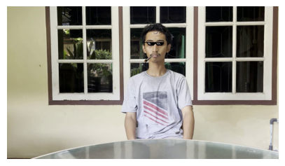

```python
## Show some random frame of the output video
videoCapture = cv2.VideoCapture('attachment/output.avi')
video_frames = []
while True:
    ret, frame = videoCapture.read()
    if not ret:
        break
    frame = cv2.cvtColor(frame, cv2.COLOR_BGR2RGB)
    video_frames.append(frame)

frames_array = np.array(video_frames)
videoCapture.release()

## Show the example of images
single_img = frames_array[200].copy()
plt.figure(figsize=(5, 5))
plt.imshow(single_img)
plt.axis('off')
plt.show()
```

### Optical Flow / Face Tracking with Mediapipe

Karena kode dari mediapipe itu sendiri akan melakukan tracking / deteksi wajah untuk setiap frame video. Kita bisa melakukan optimasi parameter ketika melakukan instantiasi Face Mesh berdasarkan dokumentasi mediapipe.

```
import mediapipe as mp

mp_face_mesh = mp.solutions.face_mesh
face_mesh = mp_face_mesh.FaceMesh(
    static_image_mode=False,
    max_num_faces=1,
    refine_landmarks=True,
    min_detection_confidence=0.5,
    min_tracking_confidence=0.5
)
```

- static_image_mode (bool):
  - True: Process images (no temporal smoothing).
  - False: Optimized for video streams with temporal smoothing.
- max_num_faces (int): Maximum number of faces to detect.
- refine_landmarks (bool): Enables refinement for specific landmarks like eyes and lips.
- min_detection_confidence (float): Minimum confidence value [0.0 - 1.0] for detecting a face.
- min_tracking_confidence (float): Minimum confidence value [0.0 - 1.0] for tracking landmarks.

Berdasarkan dokumentasi ini, kita dapat meningkatkan / menurunkan kualitas dari tracking / detecing dengan melakukan set pada nilai `min_detection_confidence` ataupun `min_tracking_confidence`

Di lain sisi, penggunaan tracking seperti optical flow atau re-deteksi setiap beberap frame, kurang menurut saya karena objek png kacamata dan rokok membutuhkan landmark point, ketika terjadi perubahan gerakan kecil pada wajah, maka gambar tersebut juga akan bergerak, dan akan terakumulasi menjadi semakin menjauh dari wajah ketika menggunakan optical flow

### Referensi

- [1. Dlib in Python](https://pyimagesearch.com/2017/04/03/facial-landmarks-dlib-opencv-python/)
- [2. Lucas Canade Optical Flow](https://www.youtube.com/watch?v=6wMoHgpVUn8)
- [3. Optical Flow](https://chatgpt.com/share/6745671f-2b68-800c-a771-1aa674644e83)
- [4. Mediapipe Overview](https://chatgpt.com/c/67466eb4-1f78-800c-a440-426e349d7dc7)